# Punto 2

Jonathan Ortega

2025-11-17

```r
rm(list = ls())
setwd("C:/Users/Jonat/Documents/Diplomado/tarea_mod_8/output")   #
load("datos_minimos_accidentes_limpio.RData")                    #
```

### ¿Cuántos accidentes ocurren por mes o por año? ¿Se observan tendencias?

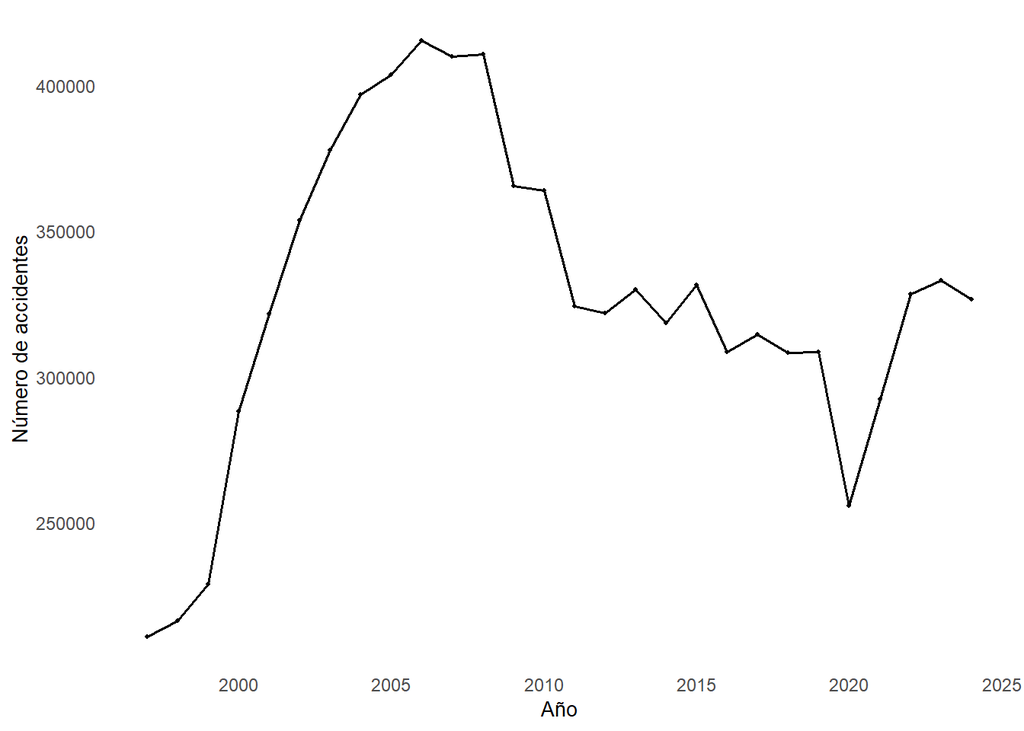

```r
library(data.table)
library(ggplot2)
library(lubridate)
library(stringr)
dt <- as.data.table(datos_minimos_accidentes_limpio)

# --- AÑOS: igual que la pasada (sin regresión/rolling) ---------------------
dt[, year := year(fecha_del_accidente)]
ann <- dt[, .N, by = year][order(year)]

p_ann <- ggplot(ann, aes(x = year, y = N)) +
  geom_line(size = 0.6) +
  geom_point(size = 0.8) +
  scale_x_continuous(breaks = pretty(ann$year, n = 8)) +
  labs(x = "Año", y = "Número de accidentes") +
  theme_minimal() +
  theme(
    panel.grid.major = element_blank(),
    panel.grid.minor = element_blank(),
    axis.title = element_text(size = 10),
    axis.text = element_text(size = 9)
  )
# --- MESES: misma versión (estadística histórica por mes: media y mediana) ---
monthly_ts <- dt[, .N, by = .(yr = year(fecha_del_accidente), m = month(fecha_del_accidente))]
monthly_stats <- monthly_ts[, .(
  mean_N   = mean(N),
  median_N = median(N),
  sd_N     = sd(N),
  iqr_N    = IQR(N)
), by = m][order(m)]
monthly_stats[, month_label := factor(m, levels = 1:12,
  labels = c("Ene","Feb","Mar","Abr","May","Jun","Jul","Ago","Sep","Oct","Nov","Dic"))]

p_month <- ggplot(monthly_stats, aes(x = month_label)) +
  geom_line(aes(y = mean_N, group = 1), size = 0.6) +
  geom_point(aes(y = mean_N), size = 0.6) +
  geom_line(aes(y = median_N, group = 1), linetype = "dashed", size = 0.6) +
  geom_point(aes(y = median_N), size = 0.6, shape = 1) +
  labs(x = "Mes", y = "Accidentes (estadísticas por mes)",
       subtitle = "Línea sólida: media; línea discontinua: mediana") +
  theme_minimal() +
  theme(panel.grid.major = element_blank(), panel.grid.minor = element_blank())

print(p_ann)
```

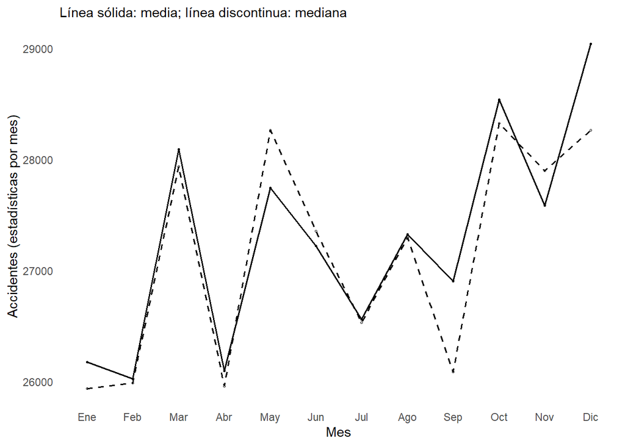

```r
print(p_month)
```

Y analizando por mes, vemos que usando la media y mediana de los accidentes en esos meses en marzo, mayo y en los ultimos 3 meses del año hay más accidentes.

### ¿Qué tipo de accidente es el más común?

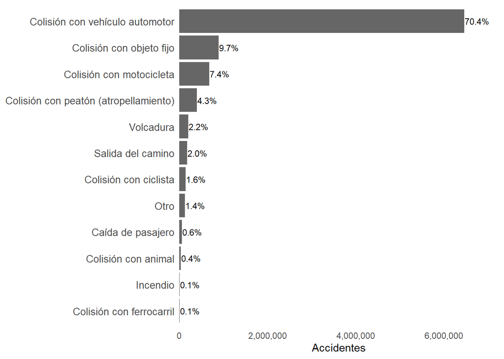

```r
tipo_counts <- dt[!is.na(tipo_de_accidente), .N, by = tipo_de_accidente][order(-N)]
tipo_counts[, pct := 100 * N / sum(N)]

ggplot(tipo_counts, aes(x = reorder(tipo_de_accidente, N), y = N)) +
  geom_col(fill = "grey40") +
  coord_flip() +
  geom_text(aes(label = paste0(sprintf("%.1f", pct), "%")),
            hjust = -0.02, size = 3) +
  scale_y_continuous(
    labels = scales::comma_format(accuracy = 1, big.mark = ","),
    limits = c(0, max(tipo_counts$N) * 1.12),
    expand = c(0, 0)
  ) +
  labs(x = NULL, y = "Accidentes") +
  theme_minimal() +
  theme(
    panel.grid.major = element_blank(),
    panel.grid.minor = element_blank(),
    axis.text.y = element_text(size = 10)
  )
```

Se ve que el tipo de accidente que predomina es el choque con un automovil.

### ¿A qué hora del día ocurren con mayor frecuencia los accidentes?

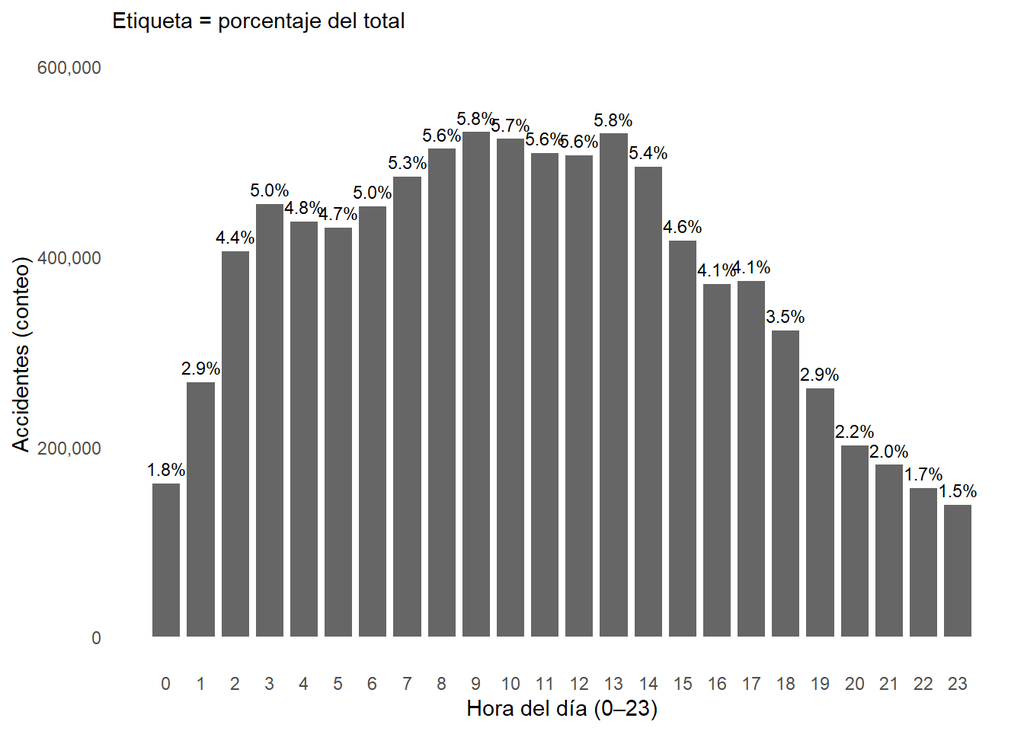

```r
library(scales)

# EXTRAER HORA y CONTAR
dt[, hour := hour(fecha_hora_accidente)]
hour_counts <- dt[!is.na(hour), .N, by = hour][order(hour)]
hour_counts[, pct := 100 * N / sum(N)]

# GRÁFICO por hora con etiqueta % (y guardado)
p_hour <- ggplot(hour_counts, aes(x = hour, y = N)) +
  geom_col(fill = "grey40", width = 0.8) +
  geom_text(aes(label = paste0(sprintf("%.1f", pct), "%")), vjust = -0.6, size = 3) +
  scale_x_continuous(breaks = 0:23) +
  scale_y_continuous(labels = scales::comma_format(accuracy = 1),
                     limits = c(0, max(hour_counts$N) * 1.12)) +
  labs(x = "Hora del día (0–23)", y = "Accidentes (conteo)",
       subtitle = "Etiqueta = porcentaje del total") +
  theme_minimal() +
  theme(panel.grid.major = element_blank(),
        panel.grid.minor = element_blank())

# Mostrar y guardar
print(p_hour)
```

```r
ggsave("accidentes_por_hora.png", p_hour, width = 10, height = 5, dpi = 150)

# AGRUPAR POR PERIODOS (Madrugada / Mañana / Tarde / Noche)
periods <- function(h) {
  cut(h, breaks = c(-1,4,11,17,23), labels = c("Madrugada","Mañana","Tarde","Noche"))
}
hour_counts[, period := periods(hour)]
period_counts <- hour_counts[, .(N = sum(N)), by = period][order(-N)]

# Imprimir las dos salidas en consola (últimas dos salidas)
print(period_counts)   # tabla resumida por periodos
```

```
##       period       N
##       <fctr>   <int>
## 1:    Mañana 3443156
## 2:     Tarde 2691840
## 3: Madrugada 1726649
## 4:     Noche 1260859
```

En la mañana hay más accidentes, pero es curioso como en la madruada pese a que hay menos movimientos hay gran cantidad de accidentes.

### ¿Qué grupos de edad o género son los más afectados?

```r
library(stringr)
# preparar columnas base
# edad_aproximada
if(!("edad_aproximada" %in% names(dt))){
  if("id_edad" %in% names(dt)) dt[, edad_aproximada := suppressWarnings(as.integer(as.character(id_edad)))]
  else dt[, edad_aproximada := NA_integer_]
} else {
  dt[, edad_aproximada := suppressWarnings(as.integer(as.character(edad_aproximada)))]
}

# genero
if(!("genero" %in% names(dt))){
  if("sexo" %in% names(dt)) dt[, genero := as.character(sexo)] else dt[, genero := NA_character_]
} else dt[, genero := as.character(genero)]

# estado de la víctima (Fallecido / Lesionado / Ileso)
if(!("estado_de_la_victima" %in% names(dt))){
  # intentar reconstruir desde indicadores si existen
  cols_m <- intersect(names(dt), c("condmuerto","pasamuerto","peatmuerto","ciclmuerto","otromuerto","nemuerto"))
  cols_h <- intersect(names(dt), c("condherido","pasaherido","peatherido","ciclherido","otroherido","neherido"))
  if(length(cols_m)) for(cn in cols_m) dt[, (cn) := suppressWarnings(as.integer(as.character(get(cn))))]
  if(length(cols_h)) for(cn in cols_h) dt[, (cn) := suppressWarnings(as.integer(as.character(get(cn))))]
  if(length(cols_m) || length(cols_h)){
    dt[, .muertos := if(length(cols_m)) rowSums(.SD, na.rm = TRUE) else 0L, .SDcols = cols_m]
    dt[, .heridos := if(length(cols_h)) rowSums(.SD, na.rm = TRUE) else 0L, .SDcols = cols_h]
    dt[, estado_de_la_victima := fifelse(.muertos > 0, "Fallecido", fifelse(.heridos > 0, "Lesionado", "Ileso"))]
    dt[, c(".muertos", ".heridos") := NULL]
  } else {
    dt[, estado_de_la_victima := if("clasacc" %in% names(dt)) fifelse(tolower(as.character(clasacc)) %like% "fatal|muert", "Fallecido", NA_character_) else NA_character_]
  }
} else dt[, estado_de_la_victima := as.character(estado_de_la_victima)]

# limpieza mínima de texto
dt[, genero := fifelse(is.na(genero) | genero=="" ,
                       NA_character_,
                       gsub("\\s+", " ", trimws(as.character(genero)))) ]
dt[ , estado_de_la_victima := fifelse(is.na(estado_de_la_victima) | estado_de_la_victima=="", NA_character_, str_squish(as.character(estado_de_la_victima)) )]

# crear cortes de edad
dt[, grupo_edad := NA_character_]
breaks <- c(-Inf,17,29,44,59,74,Inf)
labels <- c("0-17","18-29","30-44","45-59","60-74","75+")
dt[!is.na(edad_aproximada), grupo_edad := cut(edad_aproximada, breaks = breaks, labels = labels, right = TRUE)]

# resumen por grupo de edad
resumen_por_edad <- dt[ , .(
  total = .N,
  fallecidos = sum(estado_de_la_victima == "Fallecido", na.rm = TRUE),
  lesionados  = sum(estado_de_la_victima == "Lesionado", na.rm = TRUE),
  ilesos      = sum(estado_de_la_victima == "Ileso", na.rm = TRUE),
  na_estado   = sum(is.na(estado_de_la_victima))
), by = grupo_edad][order(-total)]
resumen_por_edad[, tasa_mortalidad := ifelse(total>0, fallecidos/total, NA_real_)]
resumen_por_edad[, tasa_lesion := ifelse(total>0, lesionados/total, NA_real_)]

# resumen por género

dt[!is.na(genero), genero := tolower(genero)]
dt[genero %in% c("m","h","male","masculino"), genero := "Hombre"]
dt[genero %in% c("f","female","femenino","mujer"), genero := "Mujer"]
dt[genero %in% c("no especificado","ns","na","desconocido","otro"), genero := NA_character_]
dt[!is.na(genero), genero := str_to_title(genero)]

resumen_por_genero <- dt[ , .(
  total = .N,
  fallecidos = sum(estado_de_la_victima == "Fallecido", na.rm = TRUE),
  lesionados  = sum(estado_de_la_victima == "Lesionado", na.rm = TRUE),
  ilesos      = sum(estado_de_la_victima == "Ileso", na.rm = TRUE),
  na_estado   = sum(is.na(estado_de_la_victima))
), by = genero][order(-total)]
resumen_por_genero[, tasa_mortalidad := ifelse(total>0, fallecidos/total, NA_real_)]
resumen_por_genero[, tasa_lesion := ifelse(total>0, lesionados/total, NA_real_)]


# pruebas de asociación (genero vs estado)
test_chi_genero_estado <- NULL
if(nrow(resumen_por_genero) > 0 && any(!is.na(dt$genero)) && any(!is.na(dt$estado_de_la_victima))){
  tabla_ge <- table(dt$genero, dt$estado_de_la_victima, useNA = "no")
  ok <- all(dim(tabla_ge) >= 2)
  if(ok){
    # intentar chi-sq; si falla o esperados pequeños, usar fisher
    chi_ok <- tryCatch({
      ch <- suppressWarnings(chisq.test(tabla_ge, simulate.p.value = FALSE))
      ch
    }, error = function(e) NULL)
    if(is.null(chi_ok) || any(chi_ok$expected < 5)){
      fisher_ok <- tryCatch(fisher.test(tabla_ge), error = function(e) NULL)
      test_chi_genero_estado <- if(!is.null(fisher_ok)) list(method = "fisher", result = fisher_ok) else list(method = "chi_squared_attempt", result = chi_ok)
    } else {
      test_chi_genero_estado <- list(method = "chi_squared", result = chi_ok)
    }
  }
}

# asignar resultados al entorno global
assign("resumen_por_edad", resumen_por_edad, envir = .GlobalEnv)
assign("resumen_por_genero", resumen_por_genero, envir = .GlobalEnv)
assign("test_chi_genero_estado", test_chi_genero_estado, envir = .GlobalEnv)

# outputs rápidos en consola
print(head(resumen_por_edad, 20))
```

```
##    grupo_edad   total fallecidos lesionados  ilesos na_estado tasa_mortalidad
##        <char>   <int>      <int>      <int>   <int>     <int>           <num>
## 1:      18-29 3879470      45093     873558 2960819         0     0.011623495
## 2:      30-44 2778528      22073     555497 2200958         0     0.007944134
## 3:      45-59 1231915      10327     242890  978698         0     0.008382884
## 4:        75+  675754       8721     107520  559513         0     0.012905584
## 5:      60-74  351728       3445      74294  273989         0     0.009794500
## 6:       0-17  247186       3436      82149  161601         0     0.013900464
##    tasa_lesion
##          <num>
## 1:   0.2251746
## 2:   0.1999249
## 3:   0.1971646
## 4:   0.1591112
## 5:   0.2112257
## 6:   0.3323368
```

```r
print(resumen_por_genero)
```

```
##    genero   total fallecidos lesionados  ilesos na_estado tasa_mortalidad
##    <char>   <int>      <int>      <int>   <int>     <int>           <num>
## 1: Hombre 7957172      87287    1708512 6161373         0       0.0109696
## 2:  Mujer 1207409       5808     227396  974205         0       0.0048103
##    tasa_lesion
##          <num>
## 1:   0.2147135
## 2:   0.1883339
```

Los hombres son los que tienen tasa de mortalidad (más del doble que las mujeres) y de lesión más alta (3% más), y los más jovenes menores a 17 años son los que tienen un tasa de lesión alta del 33% y de mortalidad también más alta de 1.3%.

### ¿Qué causas se reportan con mayor frecuencia (velocidad, alcohol, distracción, etc.)?

```r
cols <- c("causa_probable_del_accidente","tipo_de_accidente","tipaccid",
          "tipo_de_vehiculo","aliento","cinturon")
cols <- intersect(cols, names(dt))

norm_unique_map <- function(vec){
  orig <- unique(vec)
  orig_chr <- as.character(orig)
  norm_vals <- iconv(tolower(trimws(orig_chr)), to = "ASCII//TRANSLIT")
  norm_vals[is.na(norm_vals) | nchar(norm_vals) == 0] <- NA_character_
  idx <- match(as.character(vec), orig_chr)
  norm_vals[idx]
}

# Aplicar mapeo por columna (procesamiento pesado solo sobre únicos)
for (c in cols) set(dt, j = c, value = norm_unique_map(dt[[c]]))

# Preferir tipo_de_accidente sobre tipaccid
dt[, tipo_acc := fifelse(!is.na(tipo_de_accidente) & tipo_de_accidente != "",
                         tipo_de_accidente,
                         fifelse(!is.na(tipaccid) & tipaccid != "", tipaccid, NA_character_))]

# Recodificar 'se ignora' / 'desconocido' a NA para causa; para aliento/cinturon dejar NA también
dt[causa_probable_del_accidente %in% c("se ignora","desconocido","na"), causa_probable_del_accidente := NA_character_]
dt[aliento %in% c("se ignora","desconocido","na"), aliento := NA_character_]
dt[cinturon %in% c("se ignora","desconocido","na"), cinturon := NA_character_]

# 1) Totales por causa
cause_tot <- dt[!is.na(causa_probable_del_accidente),
                .(conteo = .N),
                by = causa_probable_del_accidente][order(-conteo)]
cause_tot[, proporcion := conteo / sum(conteo)]

# 2) Top tipos de accidente dentro de cada causa (top 5)
cause_type <- dt[!is.na(causa_probable_del_accidente) & !is.na(tipo_acc),
                 .(N = .N),
                 by = .(causa = causa_probable_del_accidente, tipo = tipo_acc)]
cause_type[, pct_within := N / sum(N), by = causa]
setorder(cause_type, causa, -N)
top_tipo_por_causa <- cause_type[, head(.SD, 5), by = causa]

# 3) Top tipos de vehículo dentro de cada causa (top 5)
cause_veh <- dt[!is.na(causa_probable_del_accidente) & !is.na(tipo_de_vehiculo),
                .(N = .N),
                by = .(causa = causa_probable_del_accidente, veh = tipo_de_vehiculo)]
cause_veh[, pct_within := N / sum(N), by = causa]
setorder(cause_veh, causa, -N)
top_veh_por_causa <- cause_veh[, head(.SD, 5), by = causa]

# 4) Aliento / cinturón: proporción por causa (mostrar top categorías por causa)
alc_by_cause <- dt[!is.na(causa_probable_del_accidente) & !is.na(aliento),
                   .(N = .N), by = .(causa = causa_probable_del_accidente, aliento)]
alc_by_cause[, pct := N / sum(N), by = causa]
setorder(alc_by_cause, causa, -N)
alc_by_cause_top <- alc_by_cause[, head(.SD, 5), by = causa]

belt_by_cause <- dt[!is.na(causa_probable_del_accidente) & !is.na(cinturon),
                    .(N = .N), by = .(causa = causa_probable_del_accidente, cinturon)]
belt_by_cause[, pct := N / sum(N), by = causa]
setorder(belt_by_cause, causa, -N)
belt_by_cause_top <- belt_by_cause[, head(.SD, 5), by = causa]

# Imprimir resultados esenciales
print(cause_tot)
```

```
##    causa_probable_del_accidente  conteo  proporcion
##                          <char>   <int>       <num>
## 1:                    conductor 7884206 0.860290940
## 2:                         otra  892169 0.097349677
## 3:    mala condicion del camino  216762 0.023652145
## 4:           falla del vehiculo   97059 0.010590664
## 5:            peaton o pasajero   74385 0.008116574
```

```r
print(top_tipo_por_causa)
```

```
##                         causa                                  tipo       N
##                        <char>                                <char>   <int>
##  1:                 conductor       colision con vehiculo automotor 5596447
##  2:                 conductor              colision con objeto fijo  748210
##  3:                 conductor              colision con motocicleta  631532
##  4:                 conductor colision con peaton (atropellamiento)  297947
##  5:                 conductor                             volcadura  161916
##  6:        falla del vehiculo       colision con vehiculo automotor   43792
##  7:        falla del vehiculo              colision con objeto fijo   19116
##  8:        falla del vehiculo                             volcadura   10209
##  9:        falla del vehiculo                     salida del camino    8187
## 10:        falla del vehiculo                                  otro    7193
## 11: mala condicion del camino       colision con vehiculo automotor  111187
## 12: mala condicion del camino              colision con objeto fijo   41488
## 13: mala condicion del camino colision con peaton (atropellamiento)   15326
```

[output cut: 41 more lines]

```r
print(top_veh_por_causa)
```

```
##                         causa               veh       N pct_within
##                        <char>            <char>   <int>      <num>
##  1:                 conductor         automovil 6776970 0.85956278
##  2:                 conductor         camioneta  572417 0.07260300
##  3:                 conductor       motocicleta  159599 0.02024288
##  4:                 conductor            camion  128964 0.01635726
##  5:                 conductor vehiculo de carga   92219 0.01169668
##  6:        falla del vehiculo         automovil   73067 0.75281015
##  7:        falla del vehiculo         camioneta    9471 0.09757982
##  8:        falla del vehiculo            camion    5824 0.06000474
##  9:        falla del vehiculo           tractor    4063 0.04186114
## 10:        falla del vehiculo vehiculo de carga    1545 0.01591815
## 11: mala condicion del camino         automovil  190163 0.87728938
## 12: mala condicion del camino         camioneta   14283 0.06589255
## 13: mala condicion del camino            camion    3388 0.01563005
## 14: mala condicion del camino vehiculo de carga    2460 0.01134885
## 15: mala condicion del camino           tractor    2438 0.01124736
## 16:                      otra         automovil  771375 0.86460637
## 17:                      otra         camioneta   67146 0.07526153
## 18:                      otra vehiculo de carga   12543 0.01405900
## 19:                      otra            camion   12392 0.01388975
## 20:                      otra       motocicleta    9939 0.01114027
## 21:         peaton o pasajero         automovil   59703 0.80262150
## 22:         peaton o pasajero         camioneta    5173 0.06954359
## 23:         peaton o pasajero vehiculo de carga    3322 0.04465954
## 24:         peaton o pasajero            camion    1703 0.02289440
## 25:         peaton o pasajero       motocicleta    1412 0.01898232
##                         causa               veh       N pct_within
```

```r
print(alc_by_cause_top)
```

```
##                         causa aliento       N        pct
##                        <char>  <char>   <int>      <num>
##  1:                 conductor      no 5311467 0.88492298
##  2:                 conductor      si  690713 0.11507702
##  3:        falla del vehiculo      no   61031 0.77136285
##  4:        falla del vehiculo      si   18090 0.22863715
##  5: mala condicion del camino      no  120380 0.92284812
##  6: mala condicion del camino      si   10064 0.07715188
##  7:                      otra      no  563079 0.85531420
##  8:                      otra      si   95251 0.14468580
##  9:         peaton o pasajero      no   53320 0.95166702
## 10:         peaton o pasajero      si    2708 0.04833298
```

```r
print(belt_by_cause_top)
```

```
##                         causa cinturon       N       pct
##                        <char>   <char>   <int>     <num>
##  1:                 conductor       no 1664734 0.5597165
##  2:                 conductor       si 1309511 0.4402835
##  3:        falla del vehiculo       no   30930 0.6913895
##  4:        falla del vehiculo       si   13806 0.3086105
##  5: mala condicion del camino       si   90686 0.7191765
##  6: mala condicion del camino       no   35411 0.2808235
##  7:                      otra       no  306680 0.6795495
##  8:                      otra       si  144619 0.3204505
##  9:         peaton o pasajero       no   19273 0.5764836
## 10:         peaton o pasajero       si   14159 0.4235164
```

Podemos ver que principalmente es por causa del comportamiento del conductor (~86% de causas). Alcohol (aliento) positivo ≈ 11%; 56% sin cinturón (que posiblemente hable más de cómo es el conductor y no una causa directa); mala condición del camino y falla del vehículo son mucho menos frecuentes (~2.4% y ~1%).